# Reproducible data analysis project

## Prediction

Predict function is used to get the expected values based on the observed values.

```r
head(predict(fit))
```

```
##           1           2           3           4           5           6
## 1303.862968  249.582603  352.785159 1486.161358  934.857061   -9.363997
```

## Multicollinearity and Linearity

```r
car::vif(fit) #to check the if there is multicollinearity between variables
```

```
##      FG.      BLK      TRB     eFG.
## 4.953107 2.715908 2.824274 4.519052
```

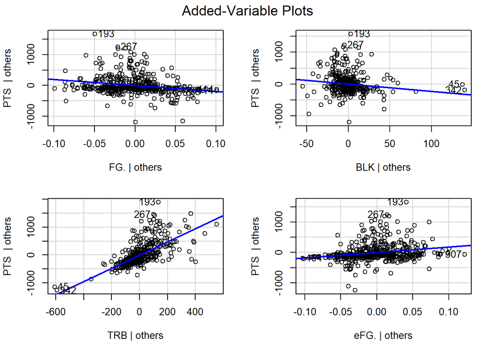

```r
#If the vif value is less than 5 there is less multicollinearity.

car::avPlots(fit) #to check the linearity.
```

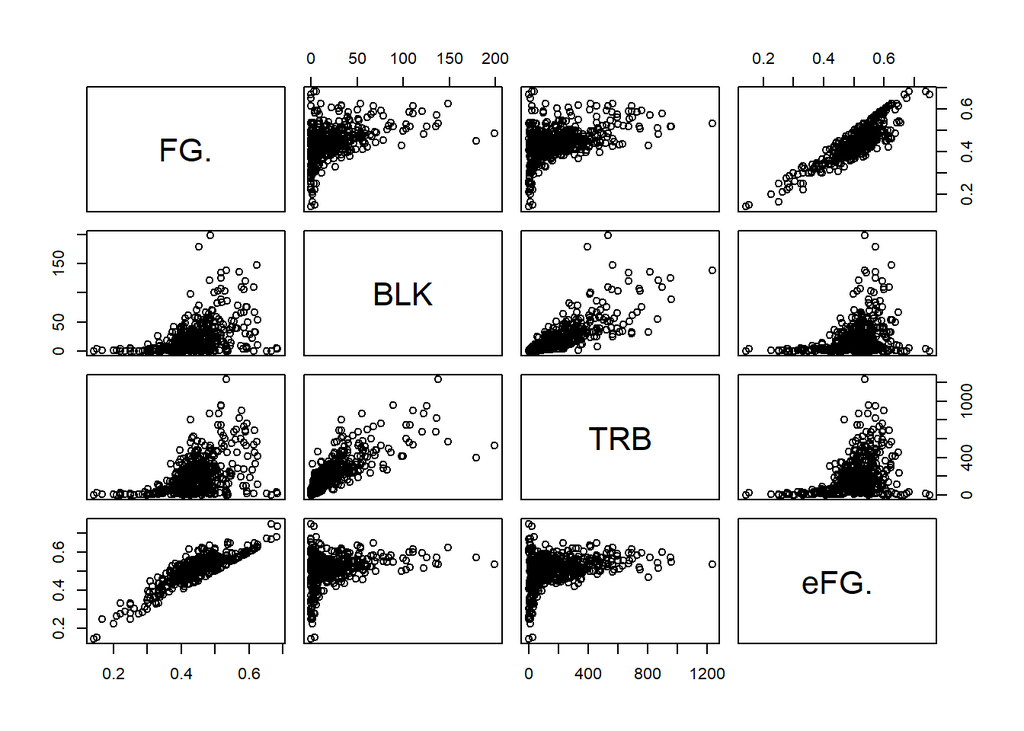

```r
pairs(formula = ~FG. + BLK + TRB + eFG., data = new_data)
```

```r
#As you can see from the graph that there are some linear non linear patterns. So thats why we can use different model which will be more efficient to our data.
```

## For Centre Position

```r
best_centre_player <- Joined_data %>% filter(Pos == 'C' | Pos == 'C-PF' | Pos == 'PF-C')
best_centre_player<- best_centre_player %>% filter(GS > mean(GS))
summary(best_centre_player)
```

```
##  player_name            Pos                 Age             Tm
##  Length:28          Length:28          Min.   :19.00   Length:28
##  Class :character   Class :character   1st Qu.:23.00   Class :character
##  Mode  :character   Mode  :character   Median :25.00   Mode  :character
##                                        Mean   :25.71
##                                        3rd Qu.:29.00
##                                        Max.   :33.00
##        G               GS              MP             FG
##  Min.   :30.00   Min.   :28.00   Min.   : 771   Min.   :178.0
##  1st Qu.:67.75   1st Qu.:50.00   1st Qu.:1656   1st Qu.:307.8
##  Median :74.00   Median :66.00   Median :1974   Median :387.5
##  Mean   :70.71   Mean   :61.07   Mean   :1952   Mean   :411.3
##  3rd Qu.:80.00   3rd Qu.:79.25   3rd Qu.:2240   3rd Qu.:514.2
##  Max.   :82.00   Max.   :81.00   Max.   :2687   Max.   :701.0
##       FGA              FG.              X3P              X3PA
##  Min.   : 345.0   Min.   :0.4520   Min.   :  0.00   Min.   :  2.00
##  1st Qu.: 532.8   1st Qu.:0.5045   1st Qu.:  4.50   1st Qu.: 27.25
##  Median : 732.0   Median :0.5245   Median : 21.50   Median : 86.50
##  Mean   : 773.3   Mean   :0.5357   Mean   : 40.61   Mean   :122.32
##  3rd Qu.: 914.2   3rd Qu.:0.5723   3rd Qu.: 74.50   3rd Qu.:203.25
##  Max.   :1354.0   Max.   :0.6240   Max.   :187.00   Max.   :512.00
##       X3P.             X2P             X2PA             X2P.
##  Min.   :0.0000   Min.   :152.0   Min.   : 274.0   Min.   :0.5130
##  1st Qu.:0.1742   1st Qu.:268.5   1st Qu.: 433.8   1st Qu.:0.5487
##  Median :0.2820   Median :366.0   Median : 606.5   Median :0.5695
##  Mean   :0.2576   Mean   :370.7   Mean   : 651.0   Mean   :0.5749
##  3rd Qu.:0.3608   3rd Qu.:486.8   3rd Qu.: 869.8   3rd Qu.:0.5907
##  Max.   :0.5000   Max.   :674.0   Max.   :1277.0   Max.   :0.6850
##       eFG.              FT             FTA           FT.
##  Min.   :0.4930   Min.   : 78.0   Min.   : 95   Min.   :0.4490
##  1st Qu.:0.5390   1st Qu.:106.8   1st Qu.:140   1st Qu.:0.7005
##  Median :0.5580   Median :140.5   Median :221   Median :0.7545
##  Mean   :0.5613   Mean   :179.9   Mean   :246   Mean   :0.7291
##  3rd Qu.:0.5805   3rd Qu.:208.5   3rd Qu.:307   3rd Qu.:0.7973
##  Max.   :0.6480   Max.   :522.0   Max.   :649   Max.   :0.8470
##       ORB             DRB             TRB              AST
##  Min.   : 33.0   Min.   :146.0   Min.   : 247.0   Min.   : 52.0
##  1st Qu.:118.2   1st Qu.:350.0   1st Qu.: 457.0   1st Qu.: 91.5
##  Median :171.0   Median :431.0   Median : 599.0   Median :113.5
##  Mean   :182.5   Mean   :442.3   Mean   : 624.8   Mean   :161.6
##  3rd Qu.:225.0   3rd Qu.:505.2   3rd Qu.: 751.0   3rd Qu.:215.0
##  Max.   :423.0   Max.   :809.0   Max.   :1232.0   Max.   :580.0
##       STL              BLK              TOV              PF
##  Min.   : 11.00   Min.   : 40.00   Min.   : 60.0   Min.   :109.0
##  1st Qu.: 42.25   1st Qu.: 66.50   1st Qu.: 84.0   1st Qu.:161.5
##  Median : 57.50   Median : 87.50   Median :102.5   Median :193.5
##  Mean   : 61.14   Mean   : 95.64   Mean   :120.0   Mean   :189.8
##  3rd Qu.: 73.50   3rd Qu.:122.75   3rd Qu.:137.2   3rd Qu.:211.0
##  Max.   :136.00   Max.   :199.00   Max.   :248.0   Max.   :292.0
##       PTS           player_id         salary
##  Min.   : 455.0   Min.   :  3.0   Min.   : 1378242
##  1st Qu.: 750.8   1st Qu.:102.5   1st Qu.: 4108000
##  Median : 945.0   Median :215.5   Median : 9643476
##  Mean   :1043.0   Mean   :247.2   Mean   :12530050
##  3rd Qu.:1211.8   3rd Qu.:370.2   3rd Qu.:22799587
##  Max.   :1880.0   Max.   :572.0   Max.   :28928710
```

```r
best_centre_player <- best_centre_player %>% filter(TRB > 620,BLK > 90,PTS >1100)
best_centre_player
```

```
## # A tibble: 6 x 31
##   player_name  Pos     Age Tm        G    GS    MP    FG   FGA   FG.   X3P  X3PA
##   <chr>        <chr> <int> <chr> <int> <int> <int> <int> <int> <dbl> <int> <int>
## 1 Andre Drumm~ C        25 DET      79    79  2647   561  1052 0.533     5    38
## 2 Anthony Dav~ C        25 NOP      56    56  1850   530  1026 0.517    48   145
## 3 Joel Embiid  C        24 PHI      64    64  2154   580  1199 0.484    79   263
## 4 Jusuf Nurkic C        24 POR      72    72  1974   420   826 0.508     3    29
## 5 Karl-Anthon~ C        23 MIN      77    77  2545   681  1314 0.518   142   355
## 6 LaMarcus Al~ C        33 SAS      81    81  2687   684  1319 0.519    10    42
## # ... with 19 more variables: X3P. <dbl>, X2P <int>, X2PA <int>, X2P. <dbl>,
## #   eFG. <dbl>, FT <int>, FTA <int>, FT. <dbl>, ORB <int>, DRB <int>,
## #   TRB <int>, AST <int>, STL <int>, BLK <int>, TOV <int>, PF <int>, PTS <int>,
## #   player_id <int>, salary <int>
```

## for Point Guard

```r
best_point_guard<- Joined_data %>% filter(Pos == 'PG')
best_point_guard<- best_point_guard %>% filter(GS > mean(GS))
summary(best_point_guard)
```

```
##  player_name            Pos                 Age             Tm
##  Length:35          Length:35          Min.   :20.00   Length:35
##  Class :character   Class :character   1st Qu.:22.00   Class :character
##  Mode  :character   Mode  :character   Median :27.00   Mode  :character
##                                        Mean   :26.06
##                                        3rd Qu.:30.00
##                                        Max.   :33.00
##        G               GS              MP             FG
##  Min.   :32.00   Min.   :28.00   Min.   : 984   Min.   :100.0
##  1st Qu.:61.50   1st Qu.:43.00   1st Qu.:1668   1st Qu.:245.5
##  Median :73.00   Median :67.00   Median :2174   Median :318.0
##  Mean   :68.43   Mean   :60.83   Mean   :2062   Mean   :390.4
##  3rd Qu.:80.50   3rd Qu.:78.00   3rd Qu.:2448   3rd Qu.:522.0
##  Max.   :82.00   Max.   :82.00   Max.   :2867   Max.   :843.0
##       FGA              FG.             X3P             X3PA
##  Min.   : 256.0   Min.   :0.391   Min.   :  0.0   Min.   :   6.0
##  1st Qu.: 536.5   1st Qu.:0.420   1st Qu.: 57.0   1st Qu.: 165.5
##  Median : 730.0   Median :0.437   Median :112.0   Median : 282.0
##  Mean   : 876.5   Mean   :0.443   Mean   :120.1   Mean   : 329.5
##  3rd Qu.:1189.5   3rd Qu.:0.467   3rd Qu.:155.5   3rd Qu.: 430.0
##  Max.   :1909.0   Max.   :0.563   Max.   :378.0   Max.   :1028.0
##       X3P.            X2P             X2PA             X2P.
##  Min.   :0.000   Min.   : 71.0   Min.   : 161.0   Min.   :0.4210
##  1st Qu.:0.329   1st Qu.:161.0   1st Qu.: 338.0   1st Qu.:0.4700
##  Median :0.359   Median :229.0   Median : 476.0   Median :0.4830
##  Mean   :0.348   Mean   :270.3   Mean   : 547.0   Mean   :0.4900
##  3rd Qu.:0.372   3rd Qu.:384.5   3rd Qu.: 790.5   3rd Qu.:0.5185
##  Max.   :0.437   Max.   :540.0   Max.   :1062.0   Max.   :0.5820
##       eFG.              FT             FTA             FT.
##  Min.   :0.4470   Min.   : 20.0   Min.   : 28.0   Min.   :0.4170
##  1st Qu.:0.4840   1st Qu.: 96.5   1st Qu.:123.0   1st Qu.:0.7500
##  Median :0.5080   Median :161.0   Median :203.0   Median :0.8190
##  Mean   :0.5093   Mean   :192.8   Mean   :238.7   Mean   :0.7897
##  3rd Qu.:0.5255   3rd Qu.:235.5   3rd Qu.:271.0   3rd Qu.:0.8515
##  Max.   :0.6040   Max.   :754.0   Max.   :858.0   Max.   :0.9160
##       ORB              DRB             TRB             AST
##  Min.   : 15.00   Min.   : 90.0   Min.   :106.0   Min.   :159.0
##  1st Qu.: 33.50   1st Qu.:171.0   1st Qu.:217.5   1st Qu.:278.0
##  Median : 45.00   Median :209.0   Median :247.0   Median :367.0
##  Mean   : 51.06   Mean   :239.1   Mean   :290.2   Mean   :402.3
##  3rd Qu.: 64.50   3rd Qu.:267.5   3rd Qu.:326.0   3rd Qu.:478.5
##  Max.   :172.00   Max.   :698.0   Max.   :807.0   Max.   :784.0
##       STL              BLK             TOV              PF
##  Min.   : 37.00   Min.   : 4.00   Min.   : 63.0   Min.   : 71.0
##  1st Qu.: 57.00   1st Qu.:14.00   1st Qu.:108.0   1st Qu.:119.0
##  Median : 72.00   Median :21.00   Median :141.0   Median :148.0
##  Mean   : 81.37   Mean   :24.37   Mean   :162.0   Mean   :153.4
##  3rd Qu.:101.00   3rd Qu.:33.50   3rd Qu.:188.5   3rd Qu.:173.5
##  Max.   :158.00   Max.   :61.00   Max.   :387.0   Max.   :265.0
##       PTS         player_id         salary
##  Min.   : 250   Min.   : 24.0   Min.   :  949000
##  1st Qu.: 663   1st Qu.:145.5   1st Qu.: 4147380
##  Median : 906   Median :368.0   Median : 7461960
##  Mean   :1094   Mean   :321.6   Mean   :12860799
##  3rd Qu.:1438   3rd Qu.:476.5   3rd Qu.:19084900
##  Max.   :2818   Max.   :569.0   Max.   :37457154
```

```r
best_point_guard <- best_point_guard %>% filter(X2P. > 0.49,AST > 400,STL > 80)
best_point_guard
```

```
## # A tibble: 8 x 31
##   player_name  Pos     Age Tm        G    GS    MP    FG   FGA   FG.   X3P  X3PA
##   <chr>        <chr> <int> <chr> <int> <int> <int> <int> <int> <dbl> <int> <int>
## 1 Ben Simmons  PG       22 PHI      79    79  2700   540   960 0.563     0     6
## 2 Damian Lill~ PG       28 POR      80    80  2838   681  1533 0.444   237   643
## 3 Darren Coll~ PG       31 IND      76    76  2143   308   659 0.467    79   194
## 4 Eric Bledsoe PG       29 MIL      78    78  2272   470   971 0.484   124   377
## 5 James Harden PG       29 HOU      78    78  2867   843  1909 0.442   378  1028
## 6 Kemba Walker PG       28 CHO      82    82  2863   731  1684 0.434   260   731
## 7 Kyle Lowry   PG       32 TOR      65    65  2213   304   739 0.411   157   453
## 8 Kyrie Irving PG       26 BOS      67    67  2214   604  1241 0.487   174   434
## # ... with 19 more variables: X3P. <dbl>, X2P <int>, X2PA <int>, X2P. <dbl>,
## #   eFG. <dbl>, FT <int>, FTA <int>, FT. <dbl>, ORB <int>, DRB <int>,
## #   TRB <int>, AST <int>, STL <int>, BLK <int>, TOV <int>, PF <int>, PTS <int>,
## #   player_id <int>, salary <int>
```

## to select shooting guard

```r
best_shooting_guard<- Joined_data %>% filter(Pos == 'SG' | Pos == 'SF-SG' | Pos == 'SG-PF' | Pos == 'SG-SF')
best_shooting_guard<- best_shooting_guard %>% filter(GS > mean(GS))
summary(best_shooting_guard)
```

```
##  player_name            Pos                 Age             Tm
##  Length:40          Length:40          Min.   :19.00   Length:40
##  Class :character   Class :character   1st Qu.:22.75   Class :character
##  Mode  :character   Mode  :character   Median :25.50   Mode  :character
##                                        Mean   :25.27
##                                        3rd Qu.:27.25
##                                        Max.   :34.00
##        G               GS              MP             FG
##  Min.   :25.00   Min.   :20.00   Min.   : 694   Min.   : 64.0
##  1st Qu.:63.75   1st Qu.:36.00   1st Qu.:1617   1st Qu.:197.5
##  Median :73.00   Median :57.50   Median :2042   Median :336.0
##  Mean   :66.90   Mean   :54.15   Mean   :1956   Mean   :355.9
##  3rd Qu.:77.25   3rd Qu.:73.25   3rd Qu.:2332   3rd Qu.:477.5
##  Max.   :82.00   Max.   :82.00   Max.   :3028   Max.   :764.0
##       FGA              FG.              X3P              X3PA
##  Min.   : 191.0   Min.   :0.3350   Min.   :  7.00   Min.   : 45.0
##  1st Qu.: 500.5   1st Qu.:0.4113   1st Qu.: 78.25   1st Qu.:225.0
##  Median : 748.0   Median :0.4280   Median :116.50   Median :325.5
##  Mean   : 804.5   Mean   :0.4327   Mean   :125.53   Mean   :340.4
##  3rd Qu.:1085.5   3rd Qu.:0.4650   3rd Qu.:167.25   3rd Qu.:437.5
##  Max.   :1609.0   Max.   :0.5050   Max.   :278.00   Max.   :651.0
##       X3P.             X2P             X2PA             X2P.
##  Min.   :0.1560   Min.   : 19.0   Min.   :  59.0   Min.   :0.3220
##  1st Qu.:0.3352   1st Qu.:111.5   1st Qu.: 232.2   1st Qu.:0.4602
##  Median :0.3540   Median :183.5   Median : 375.0   Median :0.4880
##  Mean   :0.3585   Mean   :230.4   Mean   : 464.1   Mean   :0.4837
##  3rd Qu.:0.3797   3rd Qu.:321.5   3rd Qu.: 654.8   3rd Qu.:0.5110
##  Max.   :0.4740   Max.   :624.0   Max.   :1268.0   Max.   :0.5600
##       eFG.              FT             FTA             FT.
##  Min.   :0.4350   Min.   : 18.0   Min.   : 22.0   Min.   :0.5000
##  1st Qu.:0.4888   1st Qu.: 53.5   1st Qu.: 69.0   1st Qu.:0.7315
##  Median :0.5205   Median :118.5   Median :152.0   Median :0.8025
##  Mean   :0.5168   Mean   :139.7   Mean   :174.6   Mean   :0.7873
##  3rd Qu.:0.5430   3rd Qu.:178.0   3rd Qu.:217.5   3rd Qu.:0.8343
##  Max.   :0.6220   Max.   :393.0   Max.   :485.0   Max.   :0.9280
##       ORB              DRB             TRB             AST
##  Min.   :  7.00   Min.   : 49.0   Min.   : 56.0   Min.   : 34.0
##  1st Qu.: 32.75   1st Qu.:158.8   1st Qu.:185.8   1st Qu.:108.0
##  Median : 41.00   Median :216.5   Median :253.0   Median :173.5
##  Mean   : 45.73   Mean   :210.8   Mean   :256.5   Mean   :195.7
##  3rd Qu.: 60.00   3rd Qu.:254.8   3rd Qu.:302.5   3rd Qu.:231.2
##  Max.   :106.00   Max.   :477.0   Max.   :563.0   Max.   :518.0
##       STL              BLK             TOV              PF
##  Min.   : 13.00   Min.   : 2.00   Min.   : 17.0   Min.   : 49.0
##  1st Qu.: 40.00   1st Qu.:13.00   1st Qu.: 64.0   1st Qu.:114.5
##  Median : 59.00   Median :25.00   Median : 90.5   Median :151.5
##  Mean   : 61.73   Mean   :25.23   Mean   :109.1   Mean   :150.1
##  3rd Qu.: 77.50   3rd Qu.:33.25   3rd Qu.:128.8   3rd Qu.:183.0
##  Max.   :143.00   Max.   :58.00   Max.   :264.0   Max.   :231.0
##       PTS           player_id         salary
##  Min.   : 184.0   Min.   : 37.0   Min.   :  838464
##  1st Qu.: 559.2   1st Qu.:150.2   1st Qu.: 2896350
##  Median : 924.0   Median :231.0   Median : 8571009
##  Mean   : 977.0   Mean   :252.7   Mean   :10133464
##  3rd Qu.:1384.0   3rd Qu.:366.0   3rd Qu.:16638393
##  Max.   :2099.0   Max.   :538.0   Max.   :27739975
```

```r
best_shooting_guard <- best_shooting_guard %>% filter(FG. > 0.43,eFG. > 0.524,AST > 200,PTS >1000)
best_shooting_guard
```

```
## # A tibble: 5 x 31
##   player_name  Pos     Age Tm        G    GS    MP    FG   FGA   FG.   X3P  X3PA
##   <chr>        <chr> <int> <chr> <int> <int> <int> <int> <int> <dbl> <int> <int>
## 1 Bradley Beal SG       25 WAS      82    82  3028   764  1609 0.475   209   596
## 2 Buddy Hield  SG       26 SAC      82    82  2615   623  1360 0.458   278   651
## 3 CJ McCollum  SG       27 POR      70    70  2375   571  1243 0.459   167   445
## 4 JJ Redick    SG       34 PHI      76    63  2379   452  1027 0.44    240   605
## 5 Malcolm Bro~ SG       26 MIL      64    64  1832   378   748 0.505   104   244
## # ... with 19 more variables: X3P. <dbl>, X2P <int>, X2PA <int>, X2P. <dbl>,
## #   eFG. <dbl>, FT <int>, FTA <int>, FT. <dbl>, ORB <int>, DRB <int>,
## #   TRB <int>, AST <int>, STL <int>, BLK <int>, TOV <int>, PF <int>, PTS <int>,
## #   player_id <int>, salary <int>
```

## to select small forward

```r
best_small_forward<-Joined_data %>% filter(Pos == 'SF' | Pos == 'PF-SF' | Pos == 'SF-SG' | Pos == 'SG-SF')
best_small_forward<- best_small_forward %>% filter(GS > mean(GS))
summary(best_small_forward)
```

```
##  player_name            Pos                 Age             Tm
##  Length:27          Length:27          Min.   :20.00   Length:27
##  Class :character   Class :character   1st Qu.:23.00   Class :character
##  Mode  :character   Mode  :character   Median :25.00   Mode  :character
##                                        Mean   :25.44
##                                        3rd Qu.:28.00
##                                        Max.   :34.00
##        G               GS              MP             FG           FGA
##  Min.   :26.00   Min.   :21.00   Min.   : 884   Min.   : 86   Min.   : 227.0
##  1st Qu.:53.50   1st Qu.:28.50   1st Qu.:1288   1st Qu.:201   1st Qu.: 456.5
##  Median :68.00   Median :52.00   Median :1937   Median :253   Median : 563.0
##  Mean   :63.41   Mean   :50.04   Mean   :1827   Mean   :330   Mean   : 718.8
##  3rd Qu.:77.00   3rd Qu.:72.50   3rd Qu.:2405   3rd Qu.:482   3rd Qu.:1043.5
##  Max.   :82.00   Max.   :81.00   Max.   :2841   Max.   :721   Max.   :1614.0
##       FG.              X3P             X3PA            X3P.
##  Min.   :0.3790   Min.   :  9.0   Min.   : 34.0   Min.   :0.1840
##  1st Qu.:0.4295   1st Qu.: 52.5   1st Qu.:155.0   1st Qu.:0.3245
##  Median :0.4500   Median : 79.0   Median :254.0   Median :0.3390
##  Mean   :0.4541   Mean   : 93.7   Mean   :259.3   Mean   :0.3460
##  3rd Qu.:0.4910   3rd Qu.:117.0   3rd Qu.:337.5   3rd Qu.:0.3765
##  Max.   :0.5430   Max.   :292.0   Max.   :757.0   Max.   :0.4330
##       X2P             X2PA            X2P.             eFG.
##  Min.   : 36.0   Min.   : 88.0   Min.   :0.4090   Min.   :0.4200
##  1st Qu.:142.5   1st Qu.:257.0   1st Qu.:0.4830   1st Qu.:0.5005
##  Median :191.0   Median :431.0   Median :0.5100   Median :0.5230
##  Mean   :236.3   Mean   :459.5   Mean   :0.5131   Mean   :0.5200
##  3rd Qu.:340.5   3rd Qu.:669.5   3rd Qu.:0.5460   3rd Qu.:0.5510
##  Max.   :584.0   Max.   :995.0   Max.   :0.6460   Max.   :0.5790
##        FT             FTA             FT.              ORB
##  Min.   : 13.0   Min.   : 19.0   Min.   :0.5780   Min.   : 16.00
##  1st Qu.: 68.0   1st Qu.: 84.5   1st Qu.:0.6950   1st Qu.: 38.00
##  Median : 95.0   Median :124.0   Median :0.7790   Median : 56.00
##  Mean   :156.0   Mean   :198.5   Mean   :0.7614   Mean   : 57.85
##  3rd Qu.:211.5   3rd Qu.:292.5   3rd Qu.:0.8370   3rd Qu.: 70.50
##  Max.   :453.0   Max.   :540.0   Max.   :0.9040   Max.   :138.00
##       DRB             TRB             AST             STL
##  Min.   :116.0   Min.   :145.0   Min.   : 52.0   Min.   : 17.00
##  1st Qu.:182.0   1st Qu.:242.5   1st Qu.: 87.5   1st Qu.: 43.00
##  Median :251.0   Median :323.0   Median :156.0   Median : 57.00
##  Mean   :267.4   Mean   :325.3   Mean   :171.2   Mean   : 62.93
##  3rd Qu.:340.0   3rd Qu.:403.5   3rd Qu.:197.0   3rd Qu.: 71.50
##  Max.   :523.0   Max.   :628.0   Max.   :457.0   Max.   :170.00
##       BLK            TOV              PF             PTS
##  Min.   : 1.0   Min.   : 30.0   Min.   : 43.0   Min.   : 258.0
##  1st Qu.:16.5   1st Qu.: 55.0   1st Qu.:108.5   1st Qu.: 530.5
##  Median :29.0   Median : 88.0   Median :138.0   Median : 699.0
##  Mean   :29.0   Mean   :100.7   Mean   :133.8   Mean   : 909.7
##  3rd Qu.:37.5   3rd Qu.:131.5   3rd Qu.:170.0   3rd Qu.:1333.5
##  Max.   :84.0   Max.   :225.0   Max.   :214.0   Max.   :2159.0
##    player_id         salary
##  Min.   : 17.0   Min.   :  838464
##  1st Qu.:100.0   1st Qu.: 2622678
##  Median :252.0   Median : 6700800
##  Mean   :259.8   Mean   :11745163
##  3rd Qu.:348.5   3rd Qu.:22350822
##  Max.   :564.0   Max.   :35654150
```

```r
best_small_forward <- best_small_forward %>% filter(X3P.> 0.36,FT. > 0.76,DRB> 260)#,PTS >900)
best_small_forward
```

```
## # A tibble: 7 x 31
##   player_name  Pos     Age Tm        G    GS    MP    FG   FGA   FG.   X3P  X3PA
##   <chr>        <chr> <int> <chr> <int> <int> <int> <int> <int> <dbl> <int> <int>
## 1 Bojan Bogda~ SF       29 IND      81    81  2573   522  1051 0.497   164   386
## 2 Danilo Gall~ SF       30 LAC      68    68  2059   409   884 0.463   161   372
## 3 Jayson Tatum SF       20 BOS      79    79  2455   466  1036 0.45    116   311
## 4 Kawhi Leona~ SF       27 TOR      60    60  2040   560  1129 0.496   112   302
## 5 Khris Middl~ SF       27 MIL      77    77  2393   506  1148 0.441   179   474
## 6 Nicolas Bat~ SF       30 CHO      75    72  2354   253   562 0.45    116   298
## 7 Paul George  SF       28 OKC      77    77  2841   707  1614 0.438   292   757
## # ... with 19 more variables: X3P. <dbl>, X2P <int>, X2PA <int>, X2P. <dbl>,
## #   eFG. <dbl>, FT <int>, FTA <int>, FT. <dbl>, ORB <int>, DRB <int>,
## #   TRB <int>, AST <int>, STL <int>, BLK <int>, TOV <int>, PF <int>, PTS <int>,
## #   player_id <int>, salary <int>
```

## to select power forward

```r
best_power_forward<- Joined_data %>% filter(Pos == 'PF' | Pos == 'PF-SF' | Pos == 'SG-PF' | Pos == 'C-PF' | Pos =='PF-C')
best_power_forward<- best_power_forward %>% filter(GS > mean(GS))
summary(best_power_forward)
```

```
##  player_name            Pos                 Age             Tm
##  Length:31          Length:31          Min.   :19.00   Length:31
##  Class :character   Class :character   1st Qu.:23.00   Class :character
##  Mode  :character   Mode  :character   Median :27.00   Mode  :character
##                                        Mean   :26.68
##                                        3rd Qu.:31.00
##                                        Max.   :33.00
##        G               GS              MP             FG
##  Min.   :27.00   Min.   :25.00   Min.   : 826   Min.   : 88.0
##  1st Qu.:67.00   1st Qu.:50.00   1st Qu.:1704   1st Qu.:232.0
##  Median :73.00   Median :59.00   Median :2065   Median :322.0
##  Mean   :69.61   Mean   :58.77   Mean   :1977   Mean   :334.6
##  3rd Qu.:77.50   3rd Qu.:75.00   3rd Qu.:2336   3rd Qu.:426.0
##  Max.   :82.00   Max.   :82.00   Max.   :2802   Max.   :721.0
##       FGA              FG.              X3P              X3PA
##  Min.   : 197.0   Min.   :0.3700   Min.   : 11.00   Min.   : 34.0
##  1st Qu.: 530.0   1st Qu.:0.4360   1st Qu.: 51.50   1st Qu.:154.5
##  Median : 665.0   Median :0.4620   Median : 79.00   Median :214.0
##  Mean   : 701.8   Mean   :0.4703   Mean   : 88.84   Mean   :252.2
##  3rd Qu.: 842.5   3rd Qu.:0.5005   3rd Qu.:120.50   3rd Qu.:339.5
##  Max.   :1341.0   Max.   :0.5780   Max.   :189.00   Max.   :522.0
##       X3P.             X2P             X2PA             X2P.
##  Min.   :0.2180   Min.   : 48.0   Min.   :  88.0   Min.   :0.3870
##  1st Qu.:0.3360   1st Qu.:145.5   1st Qu.: 267.0   1st Qu.:0.5120
##  Median :0.3490   Median :215.0   Median : 447.0   Median :0.5410
##  Mean   :0.3458   Mean   :245.8   Mean   : 449.6   Mean   :0.5422
##  3rd Qu.:0.3655   3rd Qu.:325.5   3rd Qu.: 613.5   3rd Qu.:0.5640
##  Max.   :0.4020   Max.   :669.0   Max.   :1044.0   Max.   :0.6880
##       eFG.              FT             FTA             FT.
##  Min.   :0.4380   Min.   : 32.0   Min.   : 46.0   Min.   :0.5930
##  1st Qu.:0.5145   1st Qu.: 72.0   1st Qu.: 91.5   1st Qu.:0.7130
##  Median :0.5330   Median :146.0   Median :173.0   Median :0.7530
##  Mean   :0.5372   Mean   :150.9   Mean   :198.8   Mean   :0.7559
##  3rd Qu.:0.5600   3rd Qu.:182.0   3rd Qu.:237.5   3rd Qu.:0.8000
##  Max.   :0.5990   Max.   :500.0   Max.   :686.0   Max.   :0.8880
##       ORB              DRB             TRB             AST
##  Min.   : 22.00   Min.   :121.0   Min.   :155.0   Min.   : 55.0
##  1st Qu.: 60.50   1st Qu.:280.0   1st Qu.:332.5   1st Qu.: 82.5
##  Median : 76.00   Median :331.0   Median :458.0   Median :129.0
##  Mean   : 95.77   Mean   :338.8   Mean   :434.5   Mean   :166.7
##  3rd Qu.:124.50   3rd Qu.:411.0   3rd Qu.:525.5   3rd Qu.:193.0
##  Max.   :219.00   Max.   :739.0   Max.   :898.0   Max.   :469.0
##       STL              BLK              TOV              PF
##  Min.   : 11.00   Min.   : 13.00   Min.   : 37.0   Min.   : 61.0
##  1st Qu.: 42.00   1st Qu.: 26.50   1st Qu.: 72.5   1st Qu.:149.5
##  Median : 53.00   Median : 39.00   Median : 95.0   Median :180.0
##  Mean   : 57.55   Mean   : 44.81   Mean   :109.5   Mean   :173.2
##  3rd Qu.: 69.50   3rd Qu.: 55.00   3rd Qu.:128.0   3rd Qu.:198.0
##  Max.   :132.00   Max.   :110.00   Max.   :268.0   Max.   :252.0
##       PTS           player_id         salary
##  Min.   : 230.0   Min.   : 15.0   Min.   : 1544951
##  1st Qu.: 660.5   1st Qu.:202.0   1st Qu.: 4598700
##  Median : 883.0   Median :266.0   Median : 8333333
##  Mean   : 909.0   Mean   :280.6   Mean   :10335821
##  3rd Qu.:1068.0   3rd Qu.:380.0   3rd Qu.:14043750
##  Max.   :1994.0   Max.   :568.0   Max.   :31873932
```

```r
best_power_forward <- best_power_forward %>% filter(FG.> 0.46,TRB > 430,BLK> 42)
best_power_forward
```

```
## # A tibble: 6 x 31
##   player_name  Pos     Age Tm        G    GS    MP    FG   FGA   FG.   X3P  X3PA
##   <chr>        <chr> <int> <chr> <int> <int> <int> <int> <int> <dbl> <int> <int>
## 1 Giannis Ant~ PF       24 MIL      72    72  2358   721  1247 0.578    52   203
## 2 Julius Rand~ PF       24 NOP      73    49  2232   571  1089 0.524    67   195
## 3 Nemanja Bje~ PF       30 SAC      77    70  1788   284   593 0.479   103   257
## 4 Noah Vonleh  PF       23 NYK      68    57  1722   207   440 0.47     46   137
## 5 Pascal Siak~ PF       24 TOR      80    79  2548   519   945 0.549    79   214
## 6 Paul Millsap PF       33 DEN      70    65  1895   322   665 0.484    58   159
## # ... with 19 more variables: X3P. <dbl>, X2P <int>, X2PA <int>, X2P. <dbl>,
## #   eFG. <dbl>, FT <int>, FTA <int>, FT. <dbl>, ORB <int>, DRB <int>,
## #   TRB <int>, AST <int>, STL <int>, BLK <int>, TOV <int>, PF <int>, PTS <int>,
## #   player_id <int>, salary <int>
```

## Summary

This project was challenging but fascinating at the same time. The key points were learning things regarding cleaning data, transforming data, data visualisation and how to develop a reproducible data. How visualisation of data makes it easy to study the statistical part of the project. Findings such as linear modelling and how to use it to find the best players was key. Limitations such as fullfilling every assumption is difficult and for robust data we could use different data modelling techniques.

## References

1. Basketball positions - Wikipedia [Internet]. En.wikipedia.org. 2021 [cited 9 May 2021]. Available from: https://en.wikipedia.org/wiki/Basketball_positions
2. → H, → B, → C, (explained) B. Basketball Positions: Key Roles and Responsibilities (explained) [Internet]. Basketball For Coaches. 2021 [cited 9 May 2021]. Available from: https://www.basketballforcoaches.com/basketball-positions/
3. Basketball: Learn all about the sport basketball [Internet]. Ducksters.com. 2021 [cited 9 May 2021]. Available from: https://www.ducksters.com/sports/basketball.php
4. Page B, Page B. Glossary | Basketball-Reference.com [Internet]. Basketball-Reference.com. 2021 [cited 10 May 2021]. Available from: https://www.basketball-reference.com/about/glossary.html#:~:text=eFG%25%20%2D%20Effective%20Field%20Goal%20Percentage,for%2010%20with%200%20threes.